# R Notebook

```r
library(ggplot2)
library(maptools)
library(reshape2)
library(PBSmapping)
library(sp)
library(mapproj)
library(plyr)
library(data.table)
library(rgeos)
library(ggmap)
library(rgdal)
library(spatstat)
library(vegan)
library(GGally)
library(raster)
library(rgdal)
library(dplyr)
library(sf)
library(kriging)
library(ggnewscale)
library(ggspatial)
library(colorRamps)

#nonfunc lib - req 4.0.2 library(marmap)

setwd("/Users/kal/Desktop")
#overlap.microbe <-read.csv("family_abund_JR3.csv", header = T)
overlap.microbe <-read.csv("pcoa_vectors.csv", header = T)
dim(overlap.microbe)
```

```
[1] 89  4
```

[figure not shown]

```r
#ggpairs(overlap.microbe)

#Lachnospiraceae

#overlap.Lachnospiraceae <- dplyr::select(overlap.microbe, Site_number, Lachnospiraceae)
#overlap.Lachnospiraceae

#dim(overlap.Lachnospiraceae)




################Format Moorea DEM so we can use it as a map###################################
dem <- raster('dtm_merged_5m.tif') ##CANNOT ACCESS FILE

dem_land <- raster("dem_land.tif")
mo.shp <- readOGR('Moorea_outline/Isle_outline_gcs84.shp')
mo.shp.dem <- spTransform(mo.shp,projection(dem_land)) # transform to same projection as dem
mo.sf <- st_as_sf(mo.shp.dem)


# land --------------------------------------------------------------------
# hill shade
slp <- terrain(dem_land,opt='slope')
asp <- terrain(dem_land,opt='aspect')
hill <- hillShade(slp,asp)# compute hillshade
plot(hill)
```

[figure not shown]

```r
# transform rasters for ggplot
dem.p  <-  rasterToPoints(dem_land)
dem.df <-  data.frame(dem.p)
colnames(dem.df) = c("x", "y", "alt")

hill.p  <-  rasterToPoints(hill)
hill.df <-  data.frame(hill.p)
colnames(hill.df) = c("x", "y", "alt")


#########Get coordinates in UTM
nuts <-read.csv("water_column_nutrients_May2021.csv", header = T)

spdf<-SpatialPointsDataFrame(coords = nuts[c('Lon','Lat')], data = nuts, proj4string = CRS("+proj=longlat +datum=WGS84 +ellps=WGS84 +towgs84=0,0,0"))
nutsUTM<-spTransform(spdf, projection(mo.shp.dem))
nutsUTM.df <- as.data.frame(nutsUTM)


#####plot

ggplot() +
  theme_bw() +
  geom_raster(data=hill.df, aes(x=x,y=y,fill = alt),show.legend=FALSE) + scale_fill_gradientn(colors = grey(50:100/100)) +
  new_scale("fill") +
  geom_sf(data = mo.sf, fill=NA, lwd = 0.2) +
  geom_point(data= nutsUTM.df, aes(Lon.1, Lat.1), size = 2)+
  coord_sf() +
  theme(axis.line=element_blank(),
        axis.text.x=element_blank(),
        axis.text.y=element_blank(),
        axis.ticks=element_blank(),
        axis.title.x=element_blank(),
        axis.title.y=element_blank()) +
    theme(panel.grid.major = element_line(color = 'white', linetype = "dashed",size = 0.5),
        plot.background=element_rect(fill='white'))
```

```r
##################################
area2.df <- nutsUTM.df[,c(2,14,15)]
head(area2.df)
```

|  | Site_number | Lon.1 | Lat.1 |
| --- | --- | --- | --- |
| 1 | 1 | 197483.2 | 8053125 |
| 2 | 2 | 197360.9 | 8052850 |
| 3 | 3 | 196303.2 | 8052823 |
| 4 | 4 | 196595.2 | 8053468 |
| 5 | 5 | 195654.7 | 8053414 |
| 6 | 6 | 195016.0 | 8054194 |

```r
micro.df <- overlap.microbe[,c(1:3)]

##colnames(micro.df) <- c("Site_number","Alcanivoracaceae", "Bacteriovoracaceae", "Bacteroidaceae", "Colwelliaceae", "Corynebacteriaceae", "Cryomorphaceae", "Desulfobulbaceae", "Flammeovirgaceae", "Flavobacteriaceae", "Hyphomicrobiaceae", "Lachnospiraceae", "Moraxellaceae", "Paenibacillaceae", "Pirellulaceae", "Piscirickettsiaceae", "Prevotellaceae",  "Pseudoalteromonadaceae", "Pseudomonadaceae", "Puniceicoccaceae", "Rhodobacteraceae", "Rhodospirillaceae", "Simkaniaceae", "Sphingomonadaceae", "Spirochaetaceae", "Streptococcaceae", "Vibrionaceae", "Xanthomonadaceae", "Xenococcaceae")

colnames(micro.df) <- c("Site_number","pcoa1", "pcoa2")

micro.df.latlong <- merge(micro.df,area2.df, by="Site_number")
head(micro.df.latlong)
```

|  | Site_number | pcoa1 | pcoa2 | Lon.1 | Lat.1 |
| --- | --- | --- | --- | --- | --- |
| 1 | 1 | -0.07787019 | -0.06667296 | 197483.2 | 8053125 |
| 2 | 2 | -0.07891104 | -0.08204752 | 197360.9 | 8052850 |
| 3 | 3 | -0.07740730 | -0.02737540 | 196303.2 | 8052823 |
| 4 | 4 | 0.07448063 | -0.05329260 | 196595.2 | 8053468 |
| 5 | 5 | -0.05113674 | -0.07566213 | 195654.7 | 8053414 |
| 6 | 6 | -0.04180752 | -0.05853450 | 195016.0 | 8054194 |

```r
str(micro.df.latlong)
```

```
'data.frame':   83 obs. of  5 variables:
 $ Site_number: int  1 2 3 4 5 6 7 8 9 10 ...
 $ pcoa1      : num  -0.0779 -0.0789 -0.0774 0.0745 -0.0511 ...
 $ pcoa2      : num  -0.0667 -0.082 -0.0274 -0.0533 -0.0757 ...
 $ Lon.1      : num  197483 197361 196303 196595 195655 ...
 $ Lat.1      : num  8053125 8052850 8052823 8053468 8053414 ...
```

```r
###

ashapem<-read.csv("nut_boundary2.csv", header = T)
ashapem<-as.matrix(ashapem[,2:3])
##### the borderpolygon object is a list that will be part of the kriging function
borderpolygon <- list(data.frame(ashapem[,1], ashapem[,2]))


head(micro.df.latlong)
```

|  | Site_number | pcoa1 | pcoa2 | Lon.1 | Lat.1 |
| --- | --- | --- | --- | --- | --- |
| 1 | 1 | -0.07787019 | -0.06667296 | 197483.2 | 8053125 |
| 2 | 2 | -0.07891104 | -0.08204752 | 197360.9 | 8052850 |
| 3 | 3 | -0.07740730 | -0.02737540 | 196303.2 | 8052823 |
| 4 | 4 | 0.07448063 | -0.05329260 | 196595.2 | 8053468 |
| 5 | 5 | -0.05113674 | -0.07566213 | 195654.7 | 8053414 |
| 6 | 6 | -0.04180752 | -0.05853450 | 195016.0 | 8054194 |

```r
#########################pcoas
krig1 <- kriging(micro.df.latlong$Lon.1, micro.df.latlong$Lat.1, micro.df.latlong$pcoa1, pixels=1000,polygons=borderpolygon) #random
str(krig1)
```

```
List of 7
 $ model        : chr "spherical"
 $ nugget       : num 0.00192
 $ range        : num 5666
 $ sill         : num 0.00249
 $ pixel        : num 13.6
 $ map          :'data.frame':  167382 obs. of  3 variables:
  ..$ x   : num [1:167382] 193569 193569 193569 193569 193569 ...
  ..$ y   : num [1:167382] 8055887 8055901 8055914 8055928 8055941 ...
  ..$ pred: num [1:167382] 0.0545 0.0557 0.057 0.0583 0.0597 ...
 $ semivariogram:'data.frame':  10 obs. of  2 variables:
  ..$ distance    : num [1:10] 436 883 1475 2106 2704 ...
  ..$ semivariance: num [1:10] 0.00183 0.00201 0.00199 0.00222 0.0024 ...
 - attr(*, "class")= chr "kriging"
```

```r
krig2 <- krig1$map
head(krig2)
```

|  | x | y | pred |
| --- | --- | --- | --- |
| 1 | 193569.5 | 8055887 | 0.05449066 |
| 2 | 193569.5 | 8055901 | 0.05570903 |
| 3 | 193569.5 | 8055914 | 0.05697753 |
| 4 | 193569.5 | 8055928 | 0.05829656 |
| 5 | 193569.5 | 8055941 | 0.05966651 |
| 6 | 193569.5 | 8055955 | 0.06108781 |

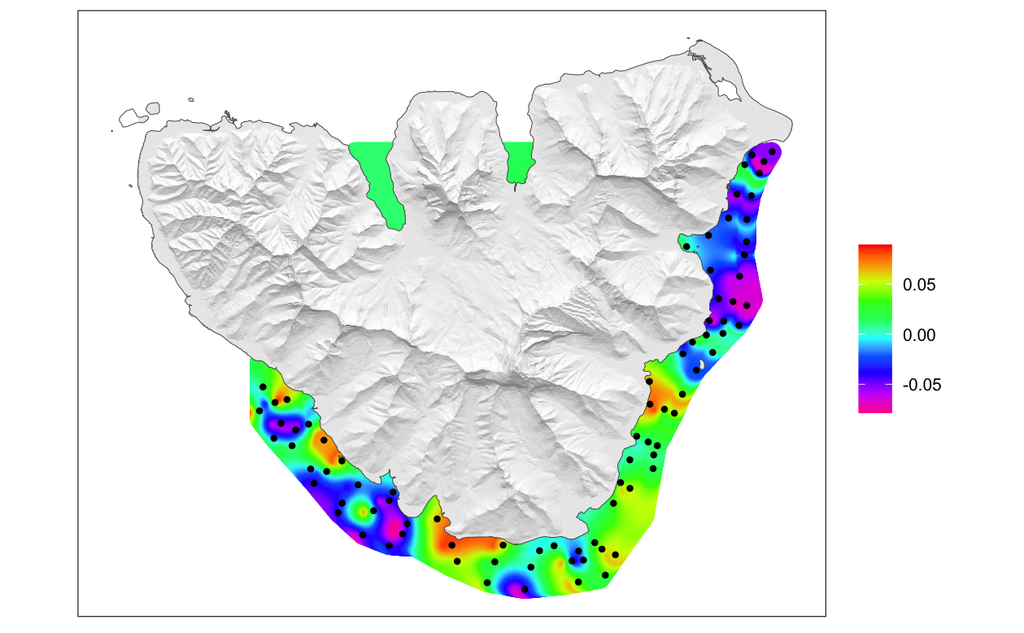

```r
#####

ggplot() +
  theme_bw() +
    geom_point(data=krig2, aes(x=x, y=y, colour=pred), size=4) +
    scale_colour_gradientn(name="",colours = rev(rainbow(10))) +
  geom_raster(data=hill.df, aes(x=x,y=y,fill = alt),show.legend=FALSE) + scale_fill_gradientn(colors = grey(50:100/100)) +
  new_scale("fill") +
  geom_sf(data = mo.sf, fill=NA, lwd = 0.2) +
  geom_point(data= micro.df.latlong, aes(Lon.1, Lat.1), size = 1)+
  coord_sf() +
  theme(axis.line=element_blank(),
        axis.text.x=element_blank(),
        axis.text.y=element_blank(),
        axis.ticks=element_blank(),
        axis.title.x=element_blank(),
        axis.title.y=element_blank()) +
    theme(panel.grid.major = element_line(color = 'white', linetype = "dashed",size = 0.5),
        plot.background=element_rect(fill='white'))
```

```r
ggsave("pcoa1", bg = "transparent", limitsize = FALSE, width = 20, height = 20, dpi = 220)
```

```
Error: Unknown graphics device ''
```

area2.df<-df

ashapem<-read.csv(“nut_boundary2.csv”, header = T) ashapem<-as.matrix(ashapem[,2:3])

##### the borderpolygon object is a list that will be part of the kriging function

borderpolygon <- list(data.frame(ashapem[,1], ashapem[,2]))

head(area2.df)

colnames(micro.df) <- c(“Site_number”,“Alcanivoracaceae”, “Bacteriovoracaceae”, “Bacteroidaceae”, “Colwelliaceae”, “Corynebacteriaceae”, “Cryomorphaceae”, “Desulfobulbaceae”, “Flammeovirgaceae”, “Flavobacteriaceae”, “Hyphomicrobiaceae”, “Lachnospiraceae”, “Moraxellaceae”, “Paenibacillaceae”, “Pirellulaceae”, “Piscirickettsiaceae”, “Prevotellaceae”, “Pseudoalteromonadaceae”, “Pseudomonadaceae”, “Puniceicoccaceae”, “Rhodobacteraceae”, “Rhodospirillaceae”, “Simkaniaceae”, “Sphingomonadaceae”, “Spirochaetaceae”, “Streptococcaceae”, “Vibrionaceae”, “Xanthomonadaceae”, “Xenococcaceae”)

head(micro.df) str(micro.df)

#ashapem<-read.csv(“nut_boundary2.csv”, header = T) #ashapem<-as.matrix(ashapem[,2:3])

#borderpolygon <- list(data.frame(ashapem[,1], ashapem[,2])) #head(micro.df)

#krig1 <- kriging(micro.df$longUTM, micro.df$latUTM, micro.df$Alcanivoracaceae + micro.df$Bacteriovoracaceae, pixels=1000,polygons=borderpolygon) ###MOD #str(krig1) #krig2 <- krig1$map

[output not shown]